# Data Science in R Final Project: Non-Residential Fire Causes

Lubov McKone

May 7, 2017

# Introduction

The grad student we are working with, Diane, has noted that there are many fires in the NFIRS databases with “undetermined” cause, particularly after 2011.

My analysis aims to investigate how the number of non-residential fires with “undetermined” causes has changed over time and by state, and determine which years and states have statistically “out of the ordinary” number of fires with undetermined causes.

# Data Cleaning and Subsetting

I used the fireincident data tables for every year from Diane’s Google Drive. If you download these files into the working directory and name them “[year]incidents” this code will run. Unfortunately I was unable to upload them myself beacuse of their size and my time constraint.

I subsetted the fireincident data tables to include only non-residential fires, and only retained the state and “cause of ignition”" columns. I created a field with the year of the data and then used sqldf to create a table for each year listing each state and a count of fire incidents with the cause of ignition listed as “U,” or undetermined. I then row-bound the tables from all of the years to create one master table listing the state, year, and number of fires with undetermined causes.

This master table is versatile.

The table can be ordered to view the data points as time series for each state, as shown below.

| STATE | YEAR | NUM_U |
| --- | --- | --- |
| AK | 2006 | 167 |
| AK | 2007 | 188 |
| AK | 2008 | 153 |
| AK | 2009 | 240 |
| AK | 2010 | 162 |
| AK | 2011 | 201 |
| AK | 2012 | 201 |
| AK | 2013 | 266 |
| AK | 2014 | 227 |
| AK | 2015 | 203 |

The table can also be arranged to view comparisons between states by year, as shown below:

| STATE | YEAR | NUM_U |
| --- | --- | --- |
| AK | 2006 | 167 |
| AL | 2006 | 1081 |
| AR | 2006 | 2172 |
| AZ | 2006 | 855 |
| CA | 2006 | 4651 |
| CO | 2006 | 866 |
| CT | 2006 | 1284 |
| DE | 2006 | 319 |
| FL | 2006 | 7516 |
| GA | 2006 | 2749 |

# Analysis

To analyze the data, I create a summary table containing the mean and variance for the number of undetermined fires in each state. I decided to examine the yearly data points for Texas to see if any values were outside 2 standard deviations from the mean.

| STATE | MEAN | STD.DEV |
| --- | --- | --- |
| TX | 7932.6 | 1587.76 |

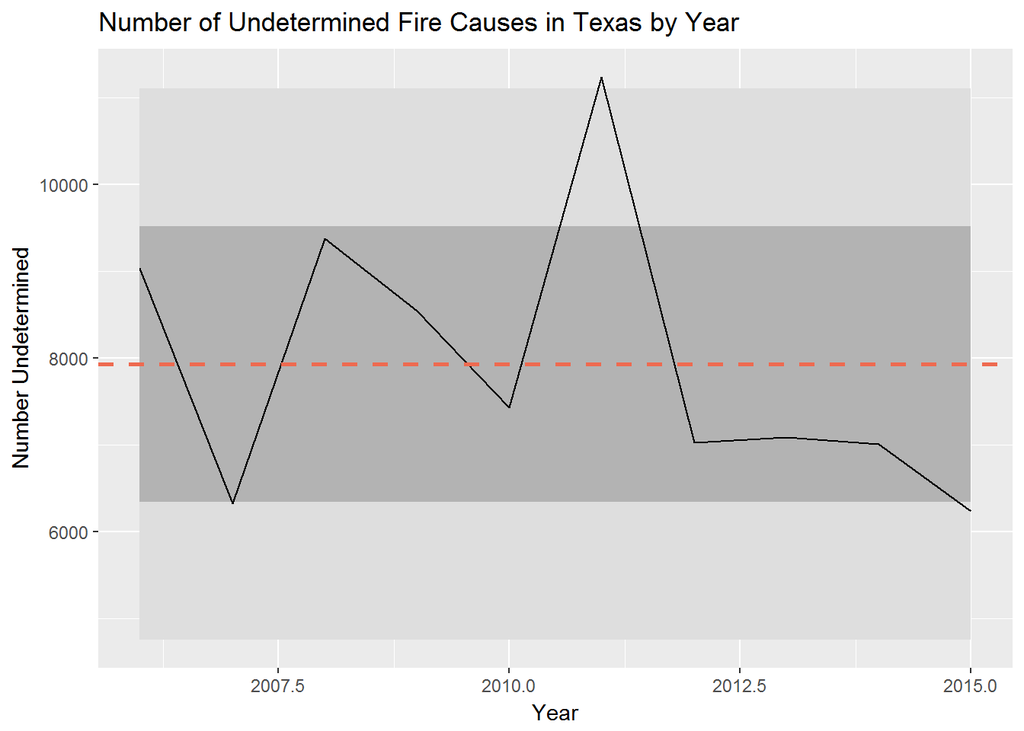

It appears that the number of fires with undetermined causes in Texas in 2011 lies outside of 2 standard deviations from the mean (represented by the dashed coral line). Since there is only a 95% chance of this happening, something must have been going on in Texas in 2011. Further analysis could focus specifially on explaining why this number is so high, perhaps using a linear regression to understand factors that contrubte to a high number of fires with undetermined causes.

# Shiny Web Application

To explore the data for yourself, visit this web application!

https://lmckone.shinyapps.io/FireApp/